# Analiza predviđanja pobjednika Oscara

Ivan Dražetić

# Analiza predviđanja pobjednika (Ivan)

## Opis problema

U ovoj analizi istražit ćemo **Možemo li pomoću dostupnih značajki pouzdano razlikovati pobjednike od ostalih?** na temelju dostupnih značajki. Za razliku od prethodnih analiza koje su se fokusirale na razlike između grupa, ova analiza koristi **logističku regresiju** kako bi modelirala vjerojatnost pobjede filma.

Cilj je utvrditi:

1. Koje značajke predviđaju pobjedu na Oscarima?
2. Koliko dobro možemo klasificirati pobjednike pomoću tih značajki?
3. Postoji li kombinacija varijabli koja omogućava pouzdanu predikciju?

Za analizu koristimo sljedeće prediktore:

- **IMDB Rating** - ocjena na IMDB platformi
- **IMDB Votes** - broj glasova korisnika (log transformacija)
- **Runtime** - trajanje filma u minutama
- **Year** - godina izlaska filma
- **Genre** - žanr filma (grupirani rijetki žanrovi)

## Analiza podataka

### Priprema podataka za logističku regresiju

Prvo učitavamo podatke i kreiramo potrebne varijable.

```r
data <- read.csv("oscars_dataset.csv", sep=";")

# Kreiranje binarne varijable ishoda
# IsWinner = 1 (pobjednik), IsWinner = 0 (nominiran bez pobjede)
data$IsWinner <- ifelse(data$Award == "Winner", 1, 0)

# Čišćenje i pretvaranje varijabli
data$Rating <- as.numeric(data$IMDB.Rating)
data$Votes <- as.numeric(gsub(",", "", data$IMDB.Votes))
data$Runtime <- as.numeric(data$Movie.Time)
data$Year <- as.numeric(data$Year.of.Release)

# Grupiranje rijetkih žanrova
common_genres <- c("Action", "Adventure", "Biography",
                   "Comedy", "Crime", "Drama")
data$GenreGroup <- ifelse(data$Main.Genre %in% common_genres,
                          data$Main.Genre, "Other")
data$GenreGroup <- factor(data$GenreGroup,
                          levels = c("Drama", "Action", "Adventure",
                                     "Biography", "Comedy", "Crime", "Other"))
```

### Finalni dataset za modeliranje

```r
model_data <- data %>%
  dplyr::select(IsWinner, Rating, Votes, Runtime, Year, GenreGroup) %>%
  na.omit()

cat("Broj filmova u analizi:", nrow(model_data), "\n")
```

```
## Broj filmova u analizi: 571
```

```r
cat("Broj pobjednika:", sum(model_data$IsWinner), "\n")
```

```
## Broj pobjednika: 94
```

```r
cat("Broj nominiranih (bez pobjede):", sum(model_data$IsWinner == 0), "\n")
```

```
## Broj nominiranih (bez pobjede): 477
```

Nakon čišćenja podataka imamo **571 filmova**, od kojih je **94 (16.5%)** pobjednika. Omjer pobjednika i nominiranih je približno **1:5**, što predstavlja klasičan problem **neuravnoteženih klasa**.

### Eksplorativna analiza

#### Usporedba IMDB ocjena

Testiramo razlikuju li se pobjednici i nominirani po IMDB ocjeni koristeći **t-test**

```r
cat("Pobjednici - Mean:",
    mean(model_data$Rating[model_data$IsWinner == 1]), "\n")
```

```
## Pobjednici - Mean: 7.779787
```

```r
cat("Nominirani - Mean:",
    mean(model_data$Rating[model_data$IsWinner == 0]), "\n")
```

```
## Nominirani - Mean: 7.52914
```

```r
t_rating <- t.test(Rating ~ IsWinner, data = model_data)
print(t_rating)
```

```
##
##  Welch Two Sample t-test
##
## data:  Rating by IsWinner
## t = -3.573, df = 120.07, p-value = 0.0005091
## alternative hypothesis: true difference in means between group 0 and group 1 is not equal to 0
## 95 percent confidence interval:
##  -0.3895394 -0.1117541
## sample estimates:
## mean in group 0 mean in group 1
##        7.529140        7.779787
```

[figure not shown]

```r
ggplot(model_data, aes(x = factor(IsWinner, labels = c("Nominee", "Winner")),
                       y = Rating, fill = factor(IsWinner))) +
  geom_boxplot(alpha = 0.7) +
  scale_fill_manual(values = c("0" = "#a6cee3", "1" = "#1f78b4")) +
  theme_minimal(base_size = 14) +
  labs(title = "IMDB ocjena: Pobjednici vs Nominirani",
       x = "", y = "IMDB Rating") +
  theme(legend.position = "none")
```

#### Usporedba broja glasova

Zbog jako skewed distribucije koristimo **Wilcoxonov test**

```r
cat("Pobjednici - Median votes:",
    median(model_data$Votes[model_data$IsWinner == 1]), "\n")
```

```
## Pobjednici - Median votes: 177533.5
```

```r
cat("Nominirani - Median votes:",
    median(model_data$Votes[model_data$IsWinner == 0]), "\n")
```

```
## Nominirani - Median votes: 41582
```

```r
wilcox_votes <- wilcox.test(Votes ~ IsWinner, data = model_data)
print(wilcox_votes)
```

```
##
##  Wilcoxon rank sum test with continuity correction
##
## data:  Votes by IsWinner
## W = 14434, p-value = 4.71e-08
## alternative hypothesis: true location shift is not equal to 0
```

[figure not shown]

```r
ggplot(model_data, aes(x = factor(IsWinner, labels = c("Nominee", "Winner")),
                       y = Votes, fill = factor(IsWinner))) +
  geom_boxplot(alpha = 0.7) +
  scale_y_log10(labels = comma) +
  scale_fill_manual(values = c("0" = "#a6cee3", "1" = "#1f78b4")) +
  theme_minimal(base_size = 14) +
  labs(title = "Broj glasova (log skala): Pobjednici vs Nominirani",
       x = "", y = "IMDB Votes (log10)") +
  theme(legend.position = "none")
```

#### Usporedba duljine filma

```r
cat("Pobjednici - Mean runtime:",
    mean(model_data$Runtime[model_data$IsWinner == 1]), "\n")
```

```
## Pobjednici - Mean runtime: 138.266
```

```r
cat("Nominirani - Mean runtime:",
    mean(model_data$Runtime[model_data$IsWinner == 0]), "\n")
```

```
## Nominirani - Mean runtime: 122.26
```

```r
t_runtime <- t.test(Runtime ~ IsWinner, data = model_data)
print(t_runtime)
```

```
##
##  Welch Two Sample t-test
##
## data:  Runtime by IsWinner
## t = -4.6816, df = 116.26, p-value = 7.767e-06
## alternative hypothesis: true difference in means between group 0 and group 1 is not equal to 0
## 95 percent confidence interval:
##  -22.777405  -9.234594
## sample estimates:
## mean in group 0 mean in group 1
##         122.260         138.266
```

#### Distribucija po žanrovima

Koristimo **Chi-squared test nezavisnosti**

```r
genre_winner_table <- table(model_data$GenreGroup, model_data$IsWinner)
addmargins(genre_winner_table)
```

```
##
##               0   1 Sum
##   Drama     173  42 215
##   Action     36   3  39
##   Adventure  36   9  45
##   Biography  83  18 101
##   Comedy     95  13 108
##   Crime      39   9  48
##   Other      15   0  15
##   Sum       477  94 571
```

```r
chisq_genre <- chisq.test(genre_winner_table)
print(chisq_genre)
```

```
##
##  Pearson's Chi-squared test
##
## data:  genre_winner_table
## X-squared = 8.8789, df = 6, p-value = 0.1805
```

Vizualizacija distribucije po žanrovima:

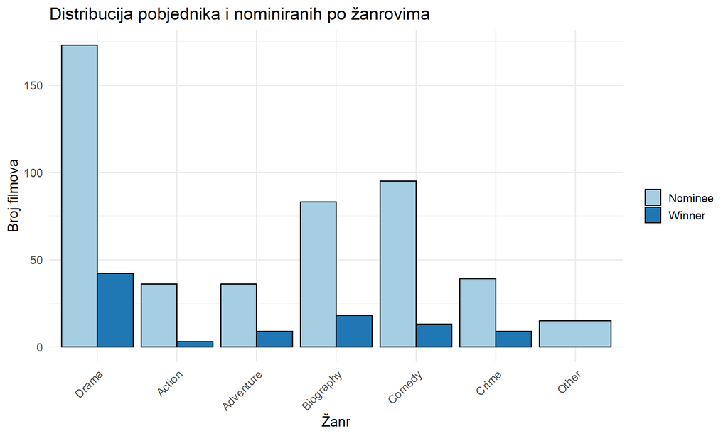

```r
genre_plot_data <- model_data %>%
  group_by(GenreGroup, IsWinner) %>%
  summarise(Count = n(), .groups = "drop") %>%
  mutate(Outcome = ifelse(IsWinner == 1, "Winner", "Nominee"))

ggplot(genre_plot_data, aes(x = GenreGroup, y = Count, fill = Outcome)) +
  geom_bar(stat = "identity", position = "dodge", color = "black") +
  scale_fill_manual(values = c("Winner" = "#1f78b4", "Nominee" = "#a6cee3")) +
  theme_minimal(base_size = 14) +
  labs(title = "Distribucija pobjednika i nominiranih po žanrovima",
       x = "Žanr", y = "Broj filmova", fill = "") +
  theme(axis.text.x = element_text(angle = 45, hjust = 1))
```

## Logistička regresija

Koristimo logističku regresiju za modeliranje binarne zavisne varijable (IsWinner)

### Model 1: Samo IMDB Rating

```r
model1 <- glm(IsWinner ~ Rating,
              data = model_data,
              family = binomial(link = "logit"))

summary(model1)
```

```
##
## Call:
## glm(formula = IsWinner ~ Rating, family = binomial(link = "logit"),
##     data = model_data)
##
## Coefficients:
##             Estimate Std. Error z value Pr(>|z|)
## (Intercept)  -8.3611     1.7364  -4.815 1.47e-06 ***
## Rating        0.8798     0.2240   3.928 8.55e-05 ***
## ---
## Signif. codes:  0 '***' 0.001 '**' 0.01 '*' 0.05 '.' 0.1 ' ' 1
##
## (Dispersion parameter for binomial family taken to be 1)
##
##     Null deviance: 510.77  on 570  degrees of freedom
## Residual deviance: 494.05  on 569  degrees of freedom
## AIC: 498.05
##
## Number of Fisher Scoring iterations: 4
```

#### McFadden’s Pseudo R²

```r
null_model <- glm(IsWinner ~ 1, data = model_data, family = binomial)
ll_null <- logLik(null_model)
ll_model1 <- logLik(model1)
mcfadden_r2_m1 <- 1 - (ll_model1 / ll_null)

cat("McFadden's Pseudo R²:", round(as.numeric(mcfadden_r2_m1), 4), "\n")
```

```
## McFadden's Pseudo R²: 0.0327
```

### Model 2: Svi prediktori

```r
model2 <- glm(IsWinner ~ Rating + log10(Votes) + Runtime + Year + GenreGroup,
              data = model_data,
              family = binomial(link = "logit"))

summary(model2)
```

```
##
## Call:
## glm(formula = IsWinner ~ Rating + log10(Votes) + Runtime + Year +
##     GenreGroup, family = binomial(link = "logit"), data = model_data)
##
## Coefficients:
##                       Estimate Std. Error z value Pr(>|z|)
## (Intercept)         115.210770  17.700672   6.509 7.57e-11 ***
## Rating               -1.770832   0.397811  -4.451 8.53e-06 ***
## log10(Votes)          3.264831   0.447109   7.302 2.83e-13 ***
## Runtime               0.016514   0.005086   3.247  0.00117 **
## Year                 -0.061292   0.008938  -6.857 7.02e-12 ***
## GenreGroupAction     -1.784374   0.664404  -2.686  0.00724 **
## GenreGroupAdventure  -0.673262   0.494484  -1.362  0.17334
## GenreGroupBiography  -0.022287   0.358982  -0.062  0.95050
## GenreGroupComedy     -0.513873   0.385988  -1.331  0.18308
## GenreGroupCrime      -0.823464   0.481372  -1.711  0.08714 .
## GenreGroupOther     -15.483637 573.192070  -0.027  0.97845
## ---
## Signif. codes:  0 '***' 0.001 '**' 0.01 '*' 0.05 '.' 0.1 ' ' 1
##
## (Dispersion parameter for binomial family taken to be 1)
##
##     Null deviance: 510.77  on 570  degrees of freedom
## Residual deviance: 392.00  on 560  degrees of freedom
## AIC: 414
##
## Number of Fisher Scoring iterations: 15
```

#### McFadden’s Pseudo R²

```r
ll_model2 <- logLik(model2)
mcfadden_r2_m2 <- 1 - (ll_model2 / ll_null)

cat("McFadden's Pseudo R²:", round(as.numeric(mcfadden_r2_m2), 4), "\n")
```

```
## McFadden's Pseudo R²: 0.2325
```

## Test omjera vjerodostojnosti (LR test)

Koristimo LR test za usporedbu modela

### LR test: Model 2 vs Null model

```r
LR_full <- -2 * (as.numeric(ll_null) - as.numeric(ll_model2))
df_full <- length(coef(model2)) - 1
p_value_full <- pchisq(LR_full, df = df_full, lower.tail = FALSE)

cat("H0: Svi regresori su redundantni\n")
```

```
## H0: Svi regresori su redundantni
```

```r
cat("H1: Barem jedan regresor nije redundantan\n\n")
```

```
## H1: Barem jedan regresor nije redundantan
```

```r
cat("LR statistika:", round(LR_full, 2), "\n")
```

```
## LR statistika: 118.76
```

```r
cat("Stupnjevi slobode:", df_full, "\n")
```

```
## Stupnjevi slobode: 10
```

```r
cat("p-vrijednost:", format.pval(p_value_full, digits = 3), "\n")
```

```
## p-vrijednost: <2e-16
```

### LR test: Model 2 vs Model 1

```r
LR_comparison <- -2 * (as.numeric(ll_model1) - as.numeric(ll_model2))
df_comparison <- length(coef(model2)) - length(coef(model1))
p_value_comparison <- pchisq(LR_comparison, df = df_comparison, lower.tail = FALSE)

cat("LR statistika:", round(LR_comparison, 2), "\n")
```

```
## LR statistika: 102.05
```

```r
cat("Stupnjevi slobode:", df_comparison, "\n")
```

```
## Stupnjevi slobode: 9
```

```r
cat("p-vrijednost:", format.pval(p_value_comparison, digits = 3), "\n")
```

```
## p-vrijednost: <2e-16
```

## Odds Ratios - Tumačenje koeficijenata

Interpretiramo koeficijente kroz Odds Ratios

```r
odds_ratios <- exp(coef(model2))
conf_int <- exp(confint(model2, quiet = TRUE))

odds_table <- data.frame(
  Predictor = names(odds_ratios),
  OddsRatio = odds_ratios,
  CI_Lower = conf_int[, 1],
  CI_Upper = conf_int[, 2]
)
rownames(odds_table) <- NULL

print(odds_table, digits = 3)
```

```
##              Predictor OddsRatio CI_Lower CI_Upper
## 1          (Intercept)  1.08e+50 3.07e+35 5.26e+65
## 2               Rating  1.70e-01 7.62e-02 3.65e-01
## 3         log10(Votes)  2.62e+01 1.13e+01 6.57e+01
## 4              Runtime  1.02e+00 1.01e+00 1.03e+00
## 5                 Year  9.41e-01 9.24e-01 9.57e-01
## 6     GenreGroupAction  1.68e-01 3.70e-02 5.42e-01
## 7  GenreGroupAdventure  5.10e-01 1.83e-01 1.29e+00
## 8  GenreGroupBiography  9.78e-01 4.77e-01 1.96e+00
## 9     GenreGroupComedy  5.98e-01 2.73e-01 1.25e+00
## 10     GenreGroupCrime  4.39e-01 1.63e-01 1.09e+00
## 11     GenreGroupOther  1.89e-07       NA 2.54e+09
```

**Interpretacija Odds Ratios:**

- **OR > 1:** Povećanje regresora povećava šanse za pobjedu
- **OR < 1:** Povećanje regresora smanjuje šanse za pobjedu
- **OR = 1:** Regresor nema utjecaj

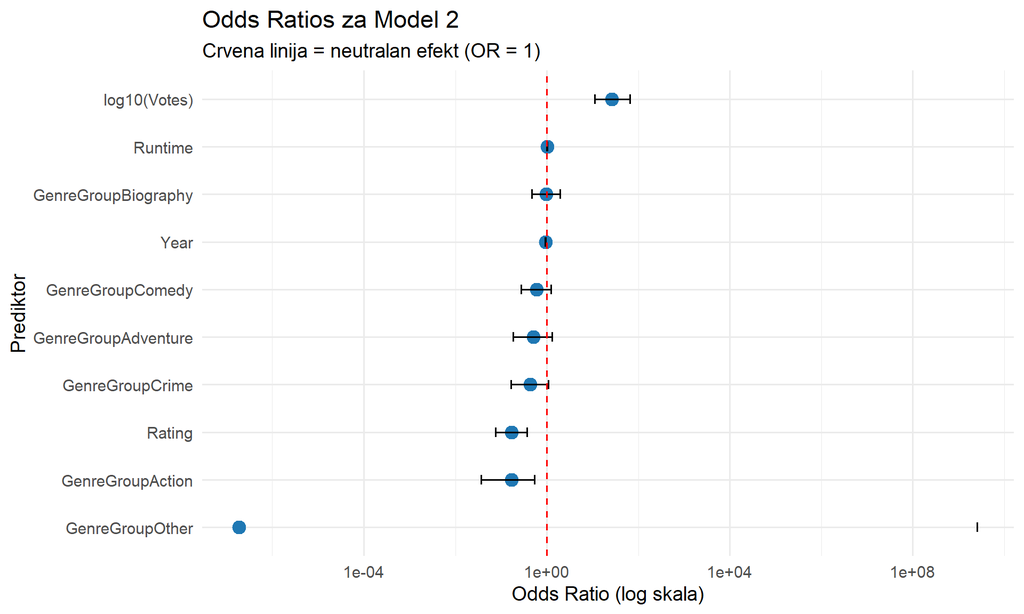

```r
odds_plot_data <- odds_table[-1, ]

ggplot(odds_plot_data, aes(x = OddsRatio, y = reorder(Predictor, OddsRatio))) +
  geom_point(size = 4, color = "#1f78b4") +
  geom_errorbarh(aes(xmin = CI_Lower, xmax = CI_Upper), height = 0.2) +
  geom_vline(xintercept = 1, linetype = "dashed", color = "red") +
  theme_minimal(base_size = 14) +
  labs(title = "Odds Ratios za Model 2",
       subtitle = "Crvena linija = neutralan efekt (OR = 1)",
       x = "Odds Ratio (log skala)",
       y = "Prediktor") +
  scale_x_log10()
```

## Predikcija i Confusion Matrix

### Izračun predikcija

```r
predicted_probs <- predict(model2, type = "response")

# Threshold postavljen na proporciju pobjednika u uzorku
threshold <- sum(model_data$IsWinner) / nrow(model_data)
cat("Odabrani threshold:", round(threshold, 3), "\n")
```

```
## Odabrani threshold: 0.165
```

```r
predicted_class <- ifelse(predicted_probs >= threshold, 1, 0)

conf_matrix <- table(Predicted = predicted_class, Actual = model_data$IsWinner)
print(conf_matrix)
```

```
##          Actual
## Predicted   0   1
##         0 353  21
##         1 124  73
```

### Metrike performansi

```r
TP <- conf_matrix[2, 2]  # True Positive
TN <- conf_matrix[1, 1]  # True Negative
FP <- conf_matrix[2, 1]  # False Positive
FN <- conf_matrix[1, 2]  # False Negative

accuracy <- (TP + TN) / sum(conf_matrix)
precision <- TP / (TP + FP)
recall <- TP / (TP + FN)
f1 <- 2 * (precision * recall) / (precision + recall)

cat("Accuracy:  ", round(accuracy, 4),
    " - postotak točnih predikcija\n")
```

```
## Accuracy:   0.7461  - postotak točnih predikcija
```

```r
cat("Precision: ", round(precision, 4),
    " - od predviđenih pobjednika, koliko je stvarno pobijedilo\n")
```

```
## Precision:  0.3706  - od predviđenih pobjednika, koliko je stvarno pobijedilo
```

```r
cat("Recall:    ", round(recall, 4),
    " - koliko stvarnih pobjednika uspijemo detektirati\n")
```

```
## Recall:     0.7766  - koliko stvarnih pobjednika uspijemo detektirati
```

```r
cat("F1 Score:  ", round(f1, 4),
    " - harmonijska sredina precision i recall\n")
```

```
## F1 Score:   0.5017  - harmonijska sredina precision i recall
```

### Vizualizacija Confusion Matrix

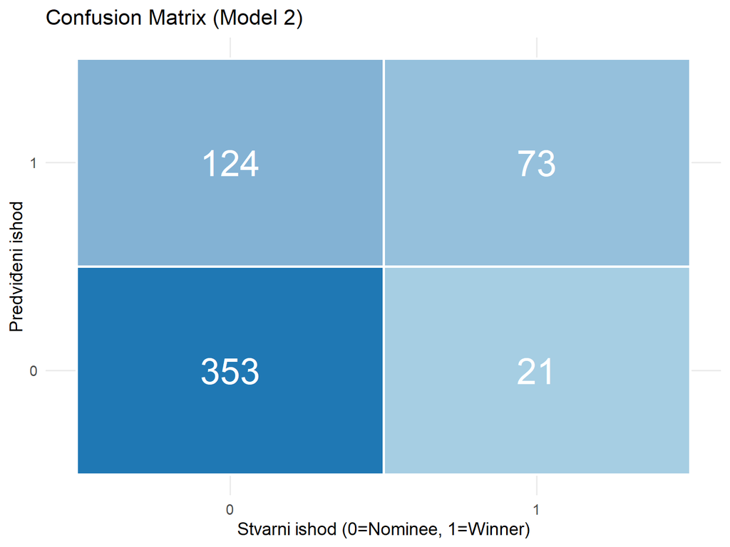

```r
conf_df <- as.data.frame(conf_matrix)
colnames(conf_df) <- c("Predicted", "Actual", "Freq")

ggplot(conf_df, aes(x = Actual, y = Predicted, fill = Freq)) +
  geom_tile(color = "white", linewidth = 1) +
  geom_text(aes(label = Freq), size = 10, color = "white") +
  scale_fill_gradient(low = "#a6cee3", high = "#1f78b4") +
  theme_minimal(base_size = 14) +
  labs(title = "Confusion Matrix (Model 2)",
       x = "Stvarni ishod (0=Nominee, 1=Winner)",
       y = "Predviđeni ishod") +
  theme(legend.position = "none")
```

### Distribucija predviđenih vjerojatnosti

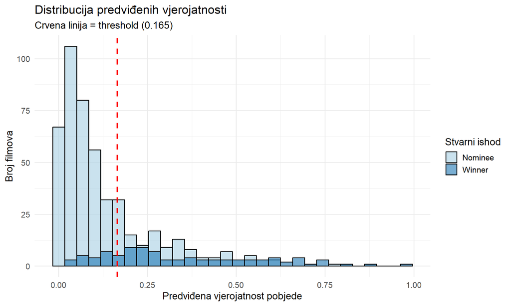

```r
pred_df <- data.frame(
  Probability = predicted_probs,
  Actual = factor(model_data$IsWinner,
                  levels = c(0, 1),
                  labels = c("Nominee", "Winner"))
)

ggplot(pred_df, aes(x = Probability, fill = Actual)) +
  geom_histogram(position = "identity", alpha = 0.6, bins = 30, color = "black") +
  geom_vline(xintercept = threshold, linetype = "dashed",
             color = "red", linewidth = 1) +
  scale_fill_manual(values = c("Nominee" = "#a6cee3", "Winner" = "#1f78b4")) +
  theme_minimal(base_size = 14) +
  labs(title = "Distribucija predviđenih vjerojatnosti",
       subtitle = paste0("Crvena linija = threshold (",
                         round(threshold, 3), ")"),
       x = "Predviđena vjerojatnost pobjede",
       y = "Broj filmova",
       fill = "Stvarni ishod")
```

## Zaključak

Na temelju rezultata logističke regresije i testova omjera vjerodostojnosti, možemo zaključiti sljedeće:

**Odgovor na glavno pitanje: Možemo li pouzdano razlikovati pobjednike?**

Djelomično DA, ali s ograničenjima.

**Pozitivni nalazi:**

1. Model ima statistički značajnu prediktivnu moć (McFadden R² = 0.233, LR test p < 0.001)
2. Broj glasova na IMDB-u je najjači prediktor pobjede
3. Model postiže 74.6% accuracy
4. 77.7% recall - detektiramo većinu stvarnih pobjednika

**Ograničenja:**

1. Precision je 37.1% - prisutno je puno lažnih pozitiva
2. Model objašnjava samo 23.3% varijance
3. 76.7% faktora ostaje neobjašnjeno (kvaliteta glume i režije, marketinška kampanja, politički i kulturni kontekst, subjektivni ukus Akademije)

**Praktična primjena:**

Model je koristan za screening - može identificirati filmove s niskim šansama, ali nije pouzdan za definitivnu predikciju pobjednika. Služi više kao dopunski alat uz druge analize.

Na temelju dostupnih podataka, možemo zaključiti da je pobjeda na Oscarima fenomen koji se ne može potpuno objasniti kvantitativnim mjerama - što potvrđuje kompleksnost i nepredvidivost umjetničkih nagrada.